# Brown Marmorated Stink Bug (*Halyomorpha halys*)

Pest species atlas

2024-11-23

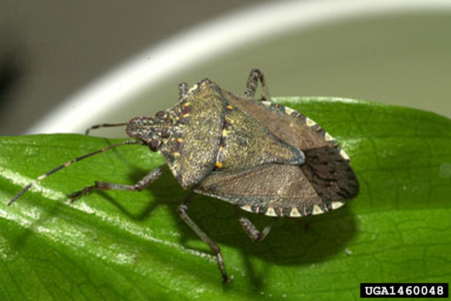

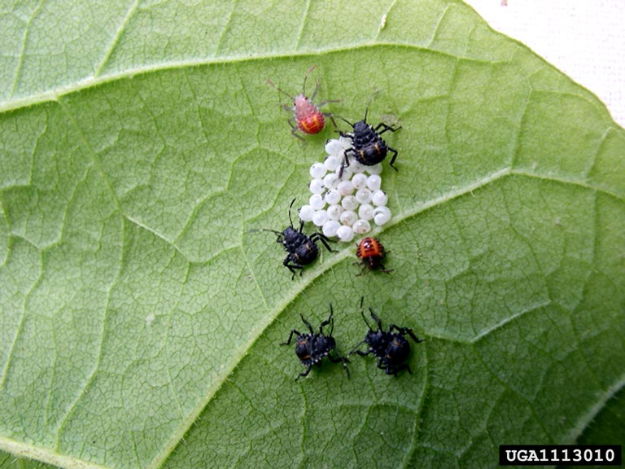

Pictures from [Maine.gov](https://www.maine.gov/dacf/php/gotpests/bugs/stink-bug.htm)

### Background

The Brown Marmorated Stink Bug (*Halyomorpha halys*) is an invasive pest species from Asia that was inadvertently introduced into the United States, possibly in the mid-1990s via a shipping container. This bug has established itself as a significant threat to farmers, predominantly in the mid-Atlantic region, due to its broad feeding range on high-value crops and ornamental plants across all life stages.

Notably, this stink bug feeds on an array of fruit, vegetable, and field crops, including apples, apricots, Asian pears, cherries, field and sweet corn, grapes, lima beans, nectarines, peaches, peppers, tomatoes, and soybeans, thereby posing a considerable agricultural risk. Detected in 38 states and the District of Columbia, it has established a wide presence across the United States.

In light of climate change, however, the future geographical distribution of this pest remains uncertain. Changing temperature patterns and weather conditions could potentially alter its current range, possibly allowing the bug to expand into areas where it’s not currently a major problem, or even shift its concentration from the mid-Atlantic region. This brings added concern for farmers outside its current dominant region as they anticipate the possible spread of this pest.

For more information, visit the [EPA](https://www.epa.gov/safepestcontrol/brown-marmorated-stink-bug) website or view their [USDA Species Profile](https://www.invasivespeciesinfo.gov/terrestrial/invertebrates/brown-marmorated-stink-bug)

## Data collected from Global Biodiversity Information Facility (GBIF)

Records were downloaded from [GBIF](https://www.gbif.org/species/4485843) and filtered to include only iNaturalist research-grade observations.  
GBIF.org (22 May 2023) GBIF Occurrence Download https://doi.org/10.15468/dl.f8mbtt

## Predicted Current and Future Habitat Suitability (0-1) of Brown Marmorated Stink Bug using research-grade iNaturalist observations

The raster layers of this map are the predicted current and future habitat suitability of Brown Marmorated Stink Bugs, with low predicted suitability in blue, increasing suitability in green and then yellow, and highest suitability in orange and red. The future predicted suitability is less certain, so relatively high suitability is yellow and orange.

[interactive chart not shown]

**You can toggle the visible layers by checking and un-checking the “Current Projected Distribution” and “Future Projected Distribution” in the top right box.** In the coming years, it is likely the distribution may shift northwards and away from the coast. Additionally, the habitat suitability will increase in inland areas it is already found.

### Top Predictors

The top predictors of current habitat suitability of the Brown Marmorated Stink Bug included:

1. bio15: Precipitation Seasonality
2. bio 18: Precipitation of Warmest Quarter
3. bio 4: Temperature Seasonality
4. gsp: growing season precipitation
5. gdd10: number of growing degree days over 10C
6. npp and gsl: potential net primary productivity and growing season length

### Model information

The ‘current’ model was created using the GBIF iNaturalist data points and a cross-validated random forest algorithm. Variables included in the model were [CHELSA + variables](https://chelsa-climate.org/exchelsa-extended-bioclim/) from 1981–2010 using the NOAA Earth system model (more information [here](https://www.envidat.ch/dataset/21d662b7-9c59-41da-aa82-7d8a879b8db7/resource/aa676d1f-5f7f-479b-af20-26066b0537d1/download/chelsa_file_specification_bioclim_plus.pdf)).

The future (2041-2070) distribution layer was created using the top model of its current distribution on projected future [CHELSA + variables](https://chelsa-climate.org/exchelsa-extended-bioclim/) in 2041-2070 assuming the ‘worst-case scenario’ shared socioeconomic pathway SSP585 and using the NOAA Earth system model (more information [here](https://www.envidat.ch/dataset/21d662b7-9c59-41da-aa82-7d8a879b8db7/resource/aa676d1f-5f7f-479b-af20-26066b0537d1/download/chelsa_file_specification_bioclim_plus.pdf)).